# Midterm

2024-03-24

Quits: Total Nonfarm

```r
quits <- fredr(series_id = "JTSQUL",
                       observation_start = as.Date("2000-12-01"),
                       observation_end = as.Date("2023-12-01")) %>%
  dplyr::select(date, series_id, value) %>%
  mutate(quits_first_diff = value - lag(value),
         quits_second_diff = difference(value, differences = 2)) %>%
  tsibble(index = date)
quits$quits <- quits$value
```

Graph of levels

```r
quit_graph <- ggplot(quits) + theme_bw() +
  geom_line(aes(x=date, y= quits),
            linewidth = 1.1) +
  ylab("Quits") +
  xlab("Date") +
  ggtitle("Quits Data (JOLTS)")

ggsave("quits.pdf", quit_graph, dpi = 300, width = 10, height = 8, bg = "white")
```

Unemployment Rate - Women Who Maintain Families

```r
emp_fam <- fredr(series_id = "LNU04000313",
                       observation_start = as.Date("2000-12-01"),
                       observation_end = as.Date("2023-12-01")) %>%
  dplyr::select(date, series_id, value) %>%
  mutate(unemp_first_diff = value - lag(value),
         unemp_second_diff = difference(value, differences = 2)) %>%
  tsibble(index = date)

emp_fam$emp_fam <- emp_fam$value
```

Plotting the levels data

```r
fam_plot <- ggplot(emp_fam) + theme_bw() +
  geom_line(aes(x=date, y= emp_fam),
            linewidth = 1.1) +
  ylab("Unemploy") +
  xlab("Date") +
  ggtitle("Unemployment Rate - Women Who Maintain Families")

ggsave("fem.pdf", fam_plot, dpi = 300, width = 10, height = 8, bg = "white")
```

Federal Funds Effective Rate

```r
fed_funds <- fredr(series_id = "FEDFUNDS",
                       observation_start = as.Date("2000-12-01"),
                       observation_end = as.Date("2023-12-01")) %>%
  dplyr::select(date, series_id, value) %>%
  mutate(fed_first_diff = value - lag(value),
         fed_second_diff = difference(value, differences = 2)) %>%
  tsibble(index = date)
fed_funds$fed_funds <- fed_funds$value
```

```r
fed_funds_plot <- ggplot(fed_funds) + theme_bw() +
  geom_line(aes(x=date, y= fed_funds),
            linewidth = 1.1) +
  ylab("Rate") +
  xlab("Date") +
  ggtitle("Federal Funds Effective Rate")

ggsave("fed_funds.pdf", fed_funds_plot, dpi = 300, width = 10, height = 8, bg = "white")
```

Average Price: Eggs, Grade A, Large (Cost per Dozen) in U.S. City Average

```r
fredr_set_key("2198d4f222b205f8ad6395cc9ec48a9d")

eggs <- fredr(series_id = "APU0000708111",
                       observation_start = as.Date("2000-12-01"),
                       observation_end = as.Date("2023-12-01")) %>%
  dplyr::select(date, series_id, value) %>%
  mutate(egg_first_diff = value - lag(value),
         egg_second_diff = difference(value, differences = 2)) %>%
  tsibble(index = date)

eggs$eggs <- eggs$value
```

```r
egg_plot <- ggplot(eggs) + theme_bw() +
  geom_line(aes(x=date, y= eggs),
            linewidth = 1.1) +
  ylab("Prices") +
  xlab("Date") +
  ggtitle("Average Price: Eggs, Grade A, Large (Cost per Dozen) in U.S. City Average")

ggsave("egg.pdf", egg_plot, dpi = 300, width = 10, height = 8, bg = "white")
```

Producing a summary statistics table

```r
data_frames_list <- list(quits,emp_fam,fed_funds,eggs)
selected_variables <- c("quits","emp_fam","fed_funds","eggs")
summary_stats_list <- list()
for (i in seq_along(data_frames_list)) {
  for (variable in selected_variables) {
    current_variable <- data_frames_list[[i]][[variable]]

    if (is.numeric(current_variable)) {
      summary_stats <- c(
        Mean = mean(current_variable, na.rm = TRUE),
        SD = sd(current_variable, na.rm = TRUE),
        Min = min(current_variable, na.rm = TRUE),
        Max = max(current_variable, na.rm = TRUE),
        N = sum(!is.na(current_variable))
      )

      summary_stats_list[[paste(names(data_frames_list)[i], variable, sep = "_")]] <- summary_stats
    }
  }
}

combined_table <- do.call(cbind, summary_stats_list)
combined_df <- as.data.frame(combined_table)
latex_table <- xtable(combined_df)
print(latex_table)
```

```
## % latex table generated in R 4.2.2 by xtable 1.8-4 package
## % Sun Mar 24 09:50:16 2024
## \begin{table}[ht]
## \centering
## \begin{tabular}{rrrrr}
##   \hline
##  & \_quits & \_emp\_fam & \_fed\_funds & \_eggs \\
##   \hline
## Mean & 2815.86 & 7.98 & 1.61 & 1.70 \\
##   SD & 651.83 & 2.48 & 1.77 & 0.56 \\
##   Min & 1555.00 & 3.60 & 0.05 & 0.86 \\
##   Max & 4515.00 & 15.90 & 6.40 & 4.82 \\
##   N & 277.00 & 277.00 & 277.00 & 277.00 \\
##    \hline
## \end{tabular}
## \end{table}
```

Creating a correlation matrix

```r
mid_data <- merge(merge(merge(eggs, emp_fam, by = "date", all = TRUE), quits, by = "date", all = TRUE), fed_funds, by = "date", all = TRUE)
corr_data <- mid_data[, c("quits", "emp_fam", "fed_funds", "eggs")]


correlation_matrix <- cor(corr_data)

# Print the correlation matrix in LaTeX format
print(xtable(correlation_matrix, caption = "Correlation Matrix"),
      caption.placement = "top",
      include.rownames = TRUE,
      include.colnames = TRUE,
      type = "latex")
```

```
## % latex table generated in R 4.2.2 by xtable 1.8-4 package
## % Sun Mar 24 09:50:16 2024
## \begin{table}[ht]
## \centering
## \caption{Correlation Matrix}
## \begin{tabular}{rrrrr}
##   \hline
##  & quits & emp\_fam & fed\_funds & eggs \\
##   \hline
## quits & 1.00 & -0.83 & 0.36 & 0.27 \\
##   emp\_fam & -0.83 & 1.00 & -0.54 & -0.14 \\
##   fed\_funds & 0.36 & -0.54 & 1.00 & -0.06 \\
##   eggs & 0.27 & -0.14 & -0.06 & 1.00 \\
##    \hline
## \end{tabular}
## \end{table}
```

Running the intord function on all the data to help make determinations about stationarity

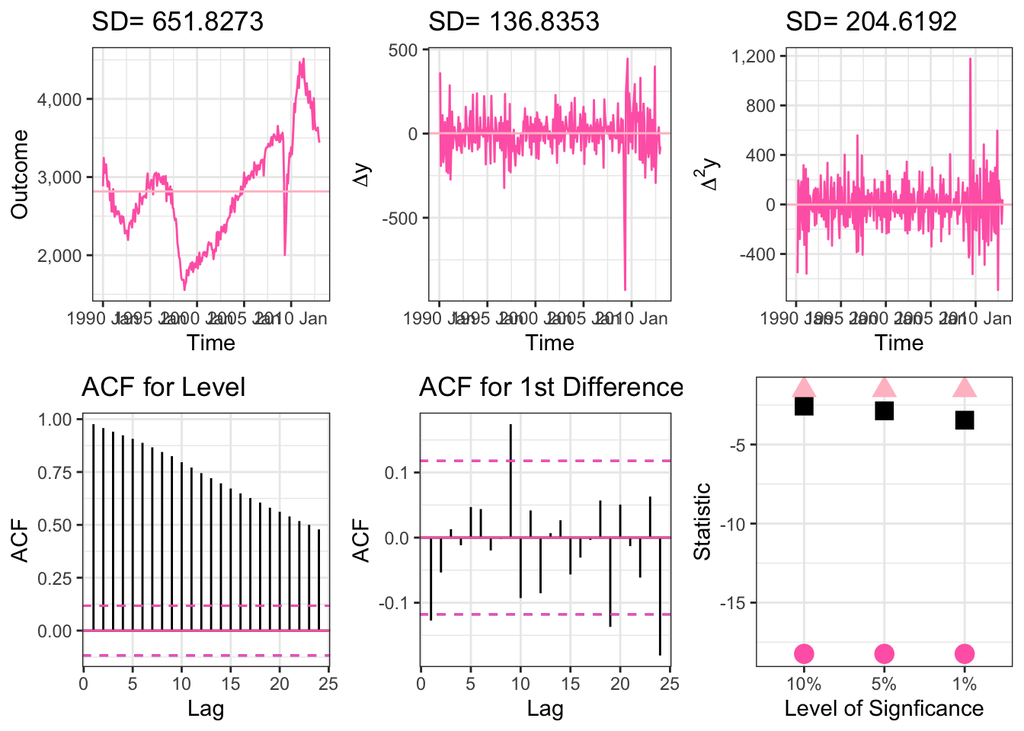

```
## $test_results
##   level crit_value ADF_round1_stat ADF_round2_stat round_1_dec round_2_dec
## 1   10%      -2.57           -1.54          -18.24         FTR         REJ
## 2    5%      -2.87           -1.54          -18.24         FTR         REJ
## 3    1%      -3.46           -1.54          -18.24         FTR         REJ
```

```r
intord(quits$quits)
```

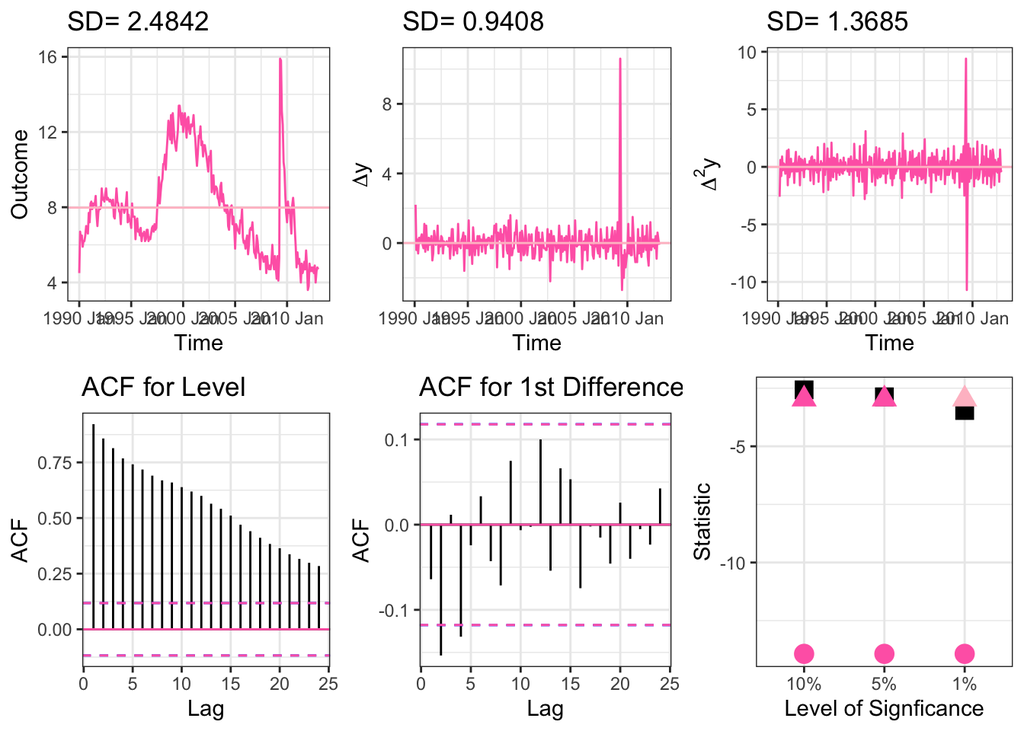

```
## $test_results
##   level crit_value ADF_round1_stat ADF_round2_stat round_1_dec round_2_dec
## 1   10%      -2.57           -2.97          -13.93         REJ         REJ
## 2    5%      -2.87           -2.97          -13.93         REJ         REJ
## 3    1%      -3.46           -2.97          -13.93         FTR         REJ
```

```r
intord(emp_fam$emp_fam)
```

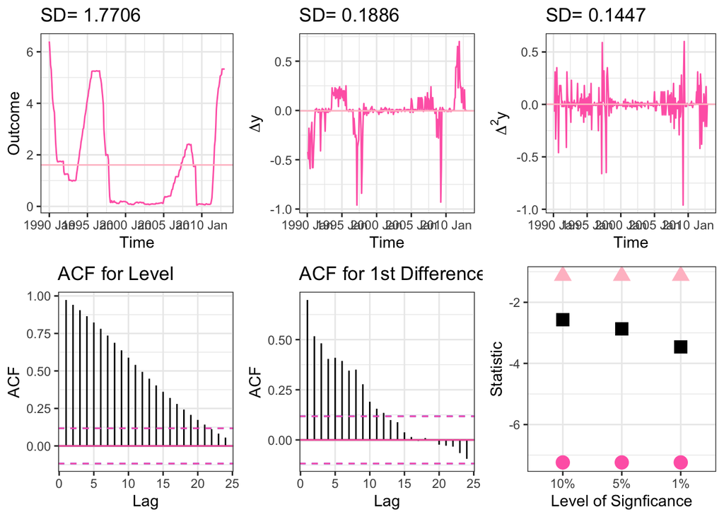

```
## $test_results
##   level crit_value ADF_round1_stat ADF_round2_stat round_1_dec round_2_dec
## 1   10%      -2.57           -1.13           -7.24         FTR         REJ
## 2    5%      -2.87           -1.13           -7.24         FTR         REJ
## 3    1%      -3.46           -1.13           -7.24         FTR         REJ
```

```r
intord(fed_funds$fed_funds)
```

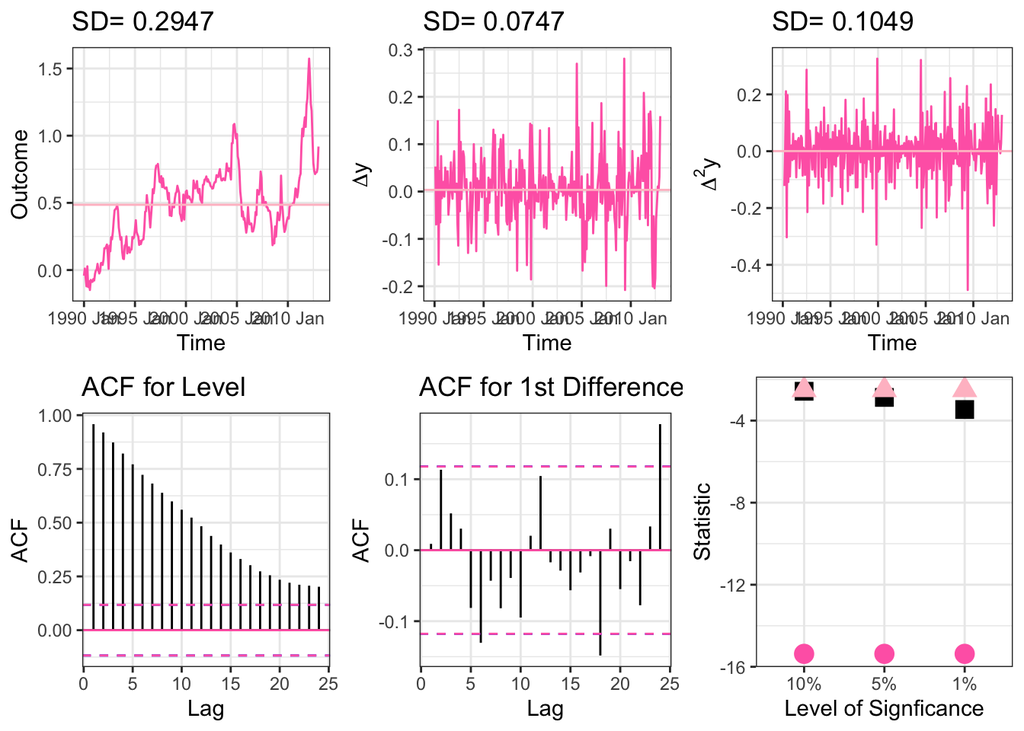

```
## $test_results
##   level crit_value ADF_round1_stat ADF_round2_stat round_1_dec round_2_dec
## 1   10%      -2.57            -2.5          -15.37         FTR         REJ
## 2    5%      -2.87            -2.5          -15.37         FTR         REJ
## 3    1%      -3.46            -2.5          -15.37         FTR         REJ
```

```r
#taking the log of egg prices to see if taking the log helps with the heteroskedasticity
eggs$log_eggs <- log(eggs$eggs)
intord(eggs$log_eggs)
```

[output not shown]

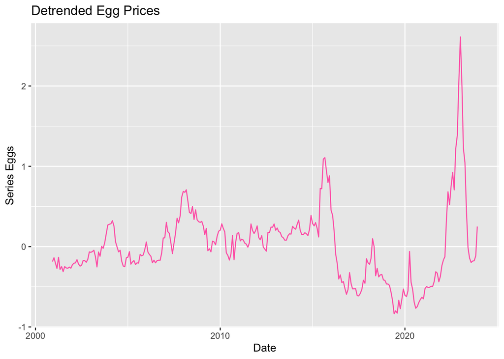

```r
eggs_trended <- lm(eggs ~ date, data = eggs)
detrend_eggs <- eggs %>%
  mutate(detrended_eggs = eggs - predict(eggs_trended ))

ggplot(data=detrend_eggs) +
  geom_line(aes(x=date, y=detrended_eggs), colour="hotpink") +
  ggtitle("Detrended Egg Prices") +
  labs(y = "Series Eggs", x = "Date")
```

Forcasting: Questions 4,5,6

Select two of your series and split them into a training set (T-6 observations) and a forecast comparison (test) set (6 observations). Using the training set and ARIMA framework, choose the best model for each series (remember these are univariate models). Provide a table with your preferred specification and at least two alternatives for each model. Discuss why you chose the model you did, make sure you use all available information to state your case. Things you should be thinking about (and discussing in your report!) while choosing your model are the model fit statistics, the presence of serial correlation (indicating model misspecification), and seasonality. Give me a clear and concise roadmap for how you arrived at the model you did.

Series 2:

```r
#set data as time series
fem_employ <- ts(emp_fam$emp_fam, start = c(2000,12),
            freq = 12)
```

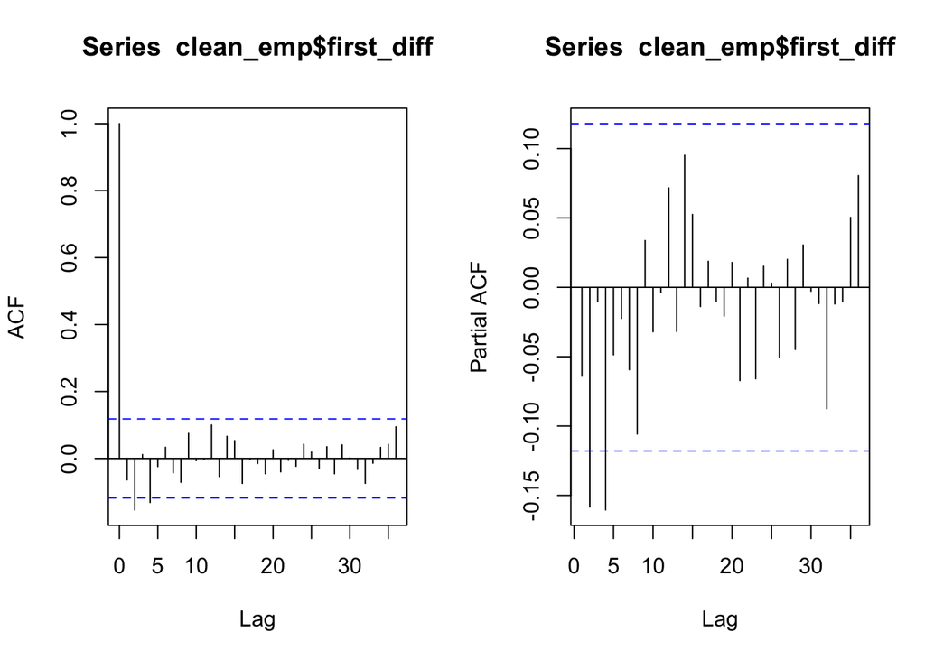

```r
#take difference for ACF and PACF
emp_fam_diff <- as.data.frame(emp_fam$unemp_first_diff)
clean_emp <- as.data.frame(emp_fam_diff[complete.cases(emp_fam_diff), ])
clean_emp$first_diff<-clean_emp$`emp_fam_diff[complete.cases(emp_fam_diff), ]`

par(mfrow = c(1,2))
acf(clean_emp$first_diff, lag.max = 36)
pacf(clean_emp$first_diff, lag.max = 36)
```

```r
#creating a training and test set
train_fem <- ts(fem_employ[1:271], start = c(2000, 12),
                freq = 12)

test_fem <- ts(fem_employ[272:277], start = c(2023,08),
           freq = 12)
```

```r
#modeling the data as an ARMA process with one difference
ts_mod_fem <- Arima(train_fem,
                order = c(1,1,1),
                xreg = time(train_fem))
summary(ts_mod_fem)
```

```
## Series: train_fem
## Regression with ARIMA(1,1,1) errors
##
## Coefficients:
##          ar1      ma1     xreg
##       0.6773  -0.8280  -0.0337
## s.e.  0.1111   0.0829   0.3649
##
## sigma^2 = 0.8699:  log likelihood = -362.84
## AIC=733.69   AICc=733.84   BIC=748.08
##
## Training set error measures:
##                       ME     RMSE       MAE        MPE     MAPE      MASE
## Training set 0.005452575 0.925761 0.5628725 -0.7870757 7.305122 0.3997367
##                    ACF1
## Training set 0.04959746
```

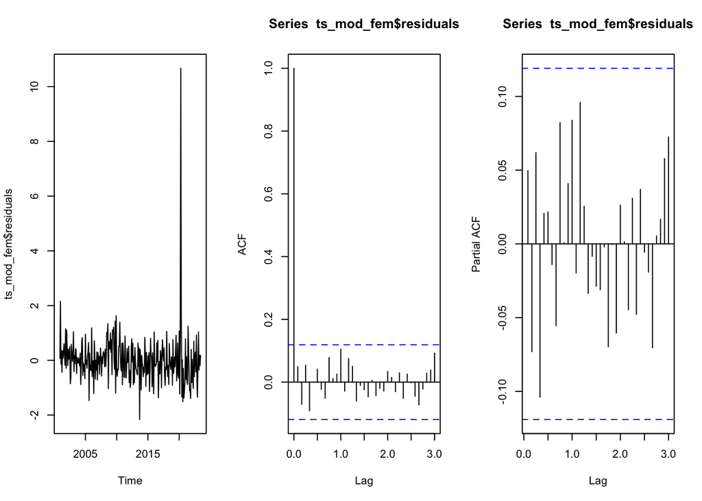

```r
par(mfrow = c(1,3))
plot(ts_mod_fem$residuals, type= 'l')
acf(ts_mod_fem$residuals, lag.max = 36)
pacf(ts_mod_fem$residuals, lag.max = 36)
```

```r
ts_mod_fem_2 <- Arima(train_fem,
                order = c(2,1,2),
                xreg = time(train_fem))
summary(ts_mod_fem_2)
```

```
## Series: train_fem
## Regression with ARIMA(2,1,2) errors
##
## Coefficients:
##           ar1     ar2      ma1      ma2     xreg
##       -0.0667  0.3852  -0.0155  -0.6093  -0.0284
## s.e.   0.1791  0.1608   0.1552   0.1412   0.3726
##
## sigma^2 = 0.8594:  log likelihood = -360.23
## AIC=732.46   AICc=732.78   BIC=754.05
##
## Training set error measures:
##                       ME      RMSE       MAE        MPE     MAPE      MASE
## Training set 0.004698726 0.9167287 0.5725914 -0.7653418 7.467131 0.4066388
##                      ACF1
## Training set -0.002773035
```

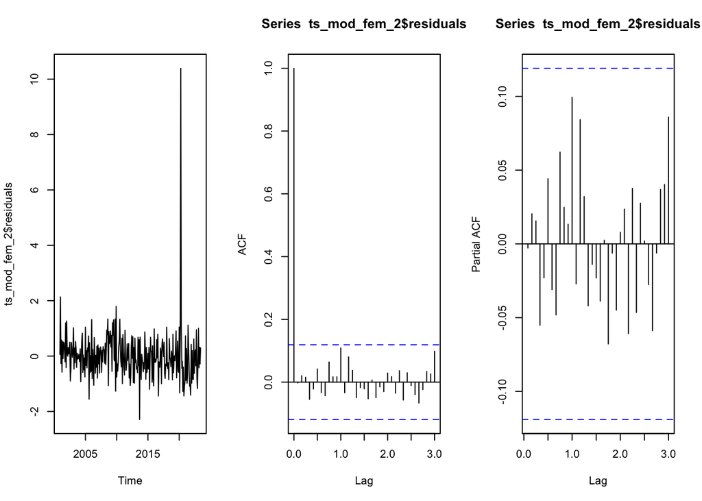

```r
par(mfrow = c(1,3))
plot(ts_mod_fem_2$residuals, type= 'l')
acf(ts_mod_fem_2$residuals, lag.max = 36)
pacf(ts_mod_fem_2$residuals, lag.max = 36)
```

```r
ts_mod_fem_3 <- Arima(train_fem,
                 order = c(3,1,3),
                 xreg = time(train_fem))
summary(ts_mod_fem_3)
```

```
## Series: train_fem
## Regression with ARIMA(3,1,3) errors
##
## Coefficients:
##           ar1     ar2     ar3     ma1      ma2      ma3     xreg
##       -0.5026  0.3421  0.2359  0.4139  -0.6004  -0.3086  -0.0277
## s.e.   2.4871  0.2269  0.9343  2.4933   0.1476   1.4988   0.3697
##
## sigma^2 = 0.8651:  log likelihood = -360.1
## AIC=736.2   AICc=736.76   BIC=764.99
##
## Training set error measures:
##                       ME      RMSE       MAE        MPE    MAPE      MASE
## Training set 0.004668723 0.9162906 0.5718137 -0.7673776 7.44421 0.4060865
##                     ACF1
## Training set 0.004946173
```

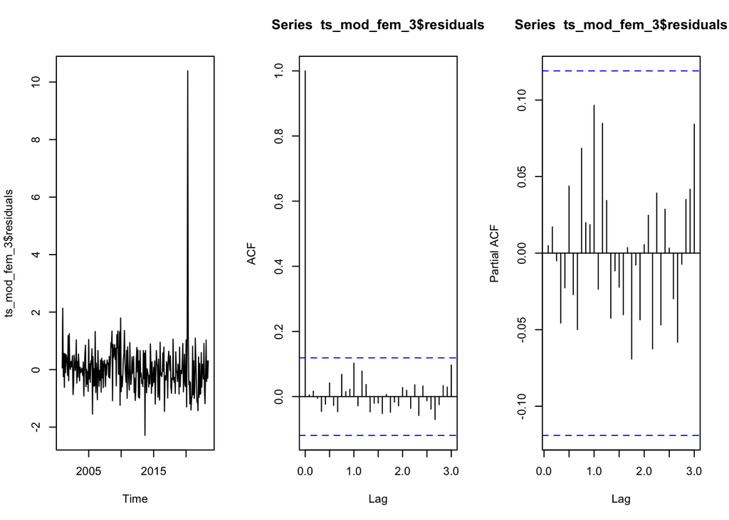

```r
par(mfrow = c(1,3))
plot(ts_mod_fem_3$residuals, type= 'l')
acf(ts_mod_fem_3$residuals, lag.max = 36)
pacf(ts_mod_fem_3$residuals, lag.max = 36)
```

# ARIMA Model Results for Series 2

|  | Model 1 (ARIMA(1,1,1)) |  | Model 2 (ARIMA(2,1,2)) |  | Model 3 (ARIMA(3,1,3)) |  |
| --- | --- | --- | --- | --- | --- | --- |
|  | Estimate | S.E. | Estimate | S.E. | Estimate | S.E. |
| ϕ1 | 0.68 | 0.11 | -0.07 | 0.18 | -0.5 | 2.49 |
| ϕ2 | NA | NA | 0.39 | 0.16 | 0.34 | 0.23 |
| ϕ3 | NA | NA | NA | NA | 0.24 | 0.93 |
| ϕ4 | - | - | - | - | - | - |
| θ1 | -0.83 | 0.08 | -0.02 | 0.16 | 0.41 | 2.49 |
| θ2 | - | - | -0.61 | 0.14 | -0.6 | 0.15 |
| θ3 | - | - | - | - | -0.31 | 1.5 |
| θ4 | - | - | - | - | - | - |
| Num. Obs | 271 |  | 271 |  | 271 |  |
| AIC | 733.6891223 |  | 732.4583581 |  | 736.2048945 |  |
| AICc | 733.84 |  | 732.78 |  | 736.76 |  |
| BIC | 748.0828101 |  | 754.0488898 |  | 764.9922702 |  |

```r
#generating predictions using the models from above
pred_mod_fem_1 <- forecast(ts_mod_fem,
                      h = 6,
                      xreg = time(test_fem))
pred_mod_fem_2 <- forecast(ts_mod_fem_2,
                      h = 6,
                      xreg = time(test_fem))
pred_mod_fem_3 <- forecast(ts_mod_fem_3,
                      h = 6,
                      xreg = time(test_fem))

mod_1_for <- autoplot(pred_mod_fem_1)
mod_2_for <- autoplot(pred_mod_fem_2)
mod_3_for <-autoplot(pred_mod_fem_3)

ggsave("mod_1_for.pdf", mod_1_for, dpi = 300, width = 10, height = 8, bg = "white")
ggsave("mod_2_for.pdf", mod_2_for, dpi = 300, width = 10, height = 8, bg = "white")
ggsave("mod_3_for.pdf", mod_3_for, dpi = 300, width = 10, height = 8, bg = "white")
```

```r
#looking at the loss functions
loss_functions <- function(predict, actual) {
predict <- as.vector(predict)
actual <- as.vector(actual)
mse <- mean((predict-actual)^2)
mae <- mean(abs(predict-actual))
mape <- mean(abs((predict-actual)/actual)*100)
msle <- mean((log(actual) - log(predict) )^2)
return(list(mse = mse,
mae = mae,
mape = mape,
msle = msle))
}


losses_1 <- loss_functions(pred_mod_fem_1$mean, test_fem)
losses_2 <- loss_functions(pred_mod_fem_2$mean, test_fem)
losses_3 <- loss_functions(pred_mod_fem_3$mean, test_fem)
losses_1
```

```
## $mse
## [1] 0.1165682
##
## $mae
## [1] 0.2363247
##
## $mape
## [1] 5.531854
##
## $msle
## [1] 0.005971117
```

```r
losses_2
```

```
## $mse
## [1] 0.1363372
##
## $mae
## [1] 0.2561144
##
## $mape
## [1] 5.990876
##
## $msle
## [1] 0.006881795
```

```r
losses_3
```

```
## $mse
## [1] 0.1416498
##
## $mae
## [1] 0.2635152
##
## $mape
## [1] 6.160224
##
## $msle
## [1] 0.007127041
```

```r
#combining the forecasts, calculating the new loss functions, and plotting the combined forecasts
xreg_forecast <- seq(272,277,1)
forecast_1 <- forecast(pred_mod_fem_1, h = 6, xreg = xreg_forecast)
forecast_2 <- forecast(pred_mod_fem_2, h = 6, xreg = xreg_forecast)
forecast_3 <- forecast(pred_mod_fem_3, h = 6, xreg = xreg_forecast)
forecast_data <- data.frame(Date = seq.Date(as.Date("2023-07-01"),
as.Date("2023-12-01"),
'months'),
test = exp(test_fem),
forecast_1 = exp(forecast_1$mean),
forecast_2 = exp(forecast_2$mean),
forecast_3 = exp(forecast_3$mean)) %>%
as_tsibble(index = Date)


comb_object <- foreccomb(observed_vector = forecast_data$test,
                         prediction_matrix = forecast_data[,-c(1,2)])
avg_forecast <- comb_SA(comb_object)


ols_forecast <- comb_OLS(comb_object)


combined_forecast_values <- ((ols_forecast$Weights[1] * forecast_1$mean)/sum(ols_forecast$Weights) +
                            (ols_forecast$Weights[2] * forecast_1$mean)/sum(ols_forecast$Weights)  +
                            (ols_forecast$Weights[3] * forecast_1$mean)/sum(ols_forecast$Weights) )


#MSE(combined_forecast_values, test_fem)
#MAE(combined_forecast_values, test_fem)

new_fem <- ts(combined_forecast_values, start = end(train_fem) + 1, frequency = frequency(train_fem))

# Combine the original time series with the forecasted values
combined_fem <- c(train_fem, new_fem)

combined_fem <- ts(combined_fem,  start = c(2000,12), freq = 12)

forecast_data <- forecast(combined_fem, h = 6)


combined_fem_plot <- autoplot(combined_fem) +
  autolayer(forecast_data, series = "Forecast") +
  autolayer(forecast_data$upper[,2], series = "Upper 99% Confidence Band") +  # Upper 99% Confidence Band
  autolayer(forecast_data$lower[,2], series = "Lower 99% Confidence Band", alpha = 0.25) +  # Lower 99% Confidence Band
  autolayer(forecast_data$upper[,1], series = "Upper 95% Confidence Band") +  # Upper 95% Confidence Band
  autolayer(forecast_data$lower[,1], series = "Lower 95% Confidence Band", alpha = 0.25) +  # Lower 95% Confidence Band
  ylab("Forecasted Unemployment for Women with Families")



ggsave("combined_fem_plot.pdf", combined_fem_plot, dpi = 300, width = 10, height = 8, bg = "white")
```

Egg Prices

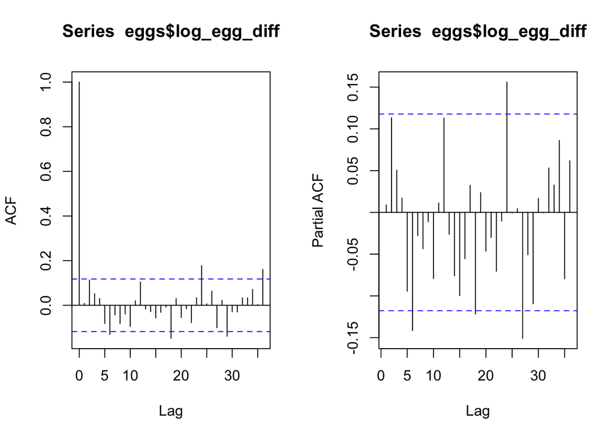

```r
#taking log of egg prices
eggs$log_egg_diff <- c(NA, diff(eggs$log_eggs))

par(mfrow = c(1,2))
acf(eggs$log_egg_diff, lag.max = 36, na.action = na.pass)
pacf(eggs$log_egg_diff, lag.max = 36, na.action = na.pass)
```

```r
#setting the data as a time series
eggs_ts <- ts(eggs$log_eggs, start = c(2000,12),
            freq = 12)

trend_eggs <- lm(eggs_ts~time(eggs_ts))
summary(trend_eggs)
```

```
##
## Call:
## lm(formula = eggs_ts ~ time(eggs_ts))
##
## Residuals:
##      Min       1Q   Median       3Q      Max
## -0.49645 -0.18639 -0.00894  0.15627  0.79205
##
## Coefficients:
##                 Estimate Std. Error t value Pr(>|t|)
## (Intercept)   -55.718142   4.147982  -13.43   <2e-16 ***
## time(eggs_ts)   0.027929   0.002061   13.55   <2e-16 ***
## ---
## Signif. codes:  0 '***' 0.001 '**' 0.01 '*' 0.05 '.' 0.1 ' ' 1
##
## Residual standard error: 0.2286 on 275 degrees of freedom
## Multiple R-squared:  0.4003, Adjusted R-squared:  0.3982
## F-statistic: 183.6 on 1 and 275 DF,  p-value: < 2.2e-16
```

```r
train_eggs <- ts(eggs_ts[1:271], start = c(2000, 12),
                freq = 12)

test_eggs <- ts(eggs_ts[272:277], start = c(2023,08),
           freq = 12)
```

```r
#generating the models that will be used for forecasting
ts_mod_eggs <- Arima(train_eggs,
                order = c(3,1,3),
                xreg = time(train_eggs))
summary(ts_mod_eggs)
```

```
## Series: train_eggs
## Regression with ARIMA(3,1,3) errors
##
## Coefficients:
##          ar1     ar2      ar3      ma1      ma2     ma3    xreg
##       0.3371  0.4102  -0.9265  -0.3397  -0.3360  0.9984  0.0384
## s.e.  0.0303  0.0222   0.0282   0.0163   0.0118  0.0207  0.0590
##
## sigma^2 = 0.005356:  log likelihood = 324.14
## AIC=-632.28   AICc=-631.73   BIC=-603.5
##
## Training set error measures:
##                         ME       RMSE        MAE      MPE     MAPE      MASE
## Training set -0.0002662489 0.07209912 0.05374924 4.857516 33.90083 0.2975832
##                     ACF1
## Training set -0.02940376
```

```r
par(mfrow = c(1,3))
plot(ts_mod_eggs$residuals, type= 'l')
acf(ts_mod_eggs$residuals, lag.max = 36)
pacf(ts_mod_eggs$residuals, lag.max = 36)
```

[output not shown]

```r
ts_mod_eggs_2 <- Arima(train_eggs,
                order = c(4,1,4),
                xreg = time(train_eggs))
summary(ts_mod_eggs_2)
```

```
## Series: train_eggs
## Regression with ARIMA(4,1,4) errors
##
## Coefficients:
##           ar1     ar2      ar3      ar4     ma1      ma2     ma3     ma4
##       -0.3542  0.3762  -0.2820  -0.9017  0.3549  -0.2674  0.3549  1.0000
## s.e.   0.0378  0.0403   0.0351   0.0359  0.0229   0.0211  0.0259  0.0248
##         xreg
##       0.0383
## s.e.  0.0578
##
## sigma^2 = 0.005106:  log likelihood = 329.82
## AIC=-639.64   AICc=-638.8   BIC=-603.66
##
## Training set error measures:
##                         ME       RMSE        MAE        MPE     MAPE      MASE
## Training set -0.0002201376 0.07012631 0.05232022 -0.3407331 34.95484 0.2896714
##                    ACF1
## Training set 0.01062153
```

```r
par(mfrow = c(1,3))
plot(ts_mod_eggs$residuals, type= 'l')
acf(ts_mod_eggs$residuals, lag.max = 36)
pacf(ts_mod_eggs$residuals, lag.max = 36)
```

[output not shown]

```r
ts_mod_eggs_3 <- Arima(train_eggs,
                 order = c(5,1,5),
                 xreg = time(train_eggs))
summary(ts_mod_eggs_3)
```

```
## Series: train_eggs
## Regression with ARIMA(5,1,5) errors
##
## Coefficients:
##           ar1     ar2      ar3      ar4     ar5      ma1      ma2     ma3
##       -0.0287  0.2692  -0.2055  -0.0686  0.8214  -0.0476  -0.2026  0.2026
## s.e.   0.0508  0.0483   0.0461   0.0488  0.0421   0.0298   0.0377  0.0420
##          ma4      ma5    xreg
##       0.0477  -1.0000  0.0314
## s.e.  0.0293   0.0391  0.0117
##
## sigma^2 = 0.005055:  log likelihood = 331.31
## AIC=-638.61   AICc=-637.4   BIC=-595.43
##
## Training set error measures:
##                       ME       RMSE        MAE        MPE     MAPE      MASE
## Training set 0.001521051 0.06950577 0.05060713 -0.3997825 34.43076 0.2801868
##                    ACF1
## Training set 0.07290055
```

```r
par(mfrow = c(1,3))
plot(ts_mod_eggs$residuals, type= 'l')
acf(ts_mod_eggs$residuals, lag.max = 36)
pacf(ts_mod_eggs$residuals, lag.max = 36)
```

[output not shown]

# ARIMA Model Results Series 4

|  | Model 1 (ARIMA(3,1,3)) |  | Model 2 (ARIMA(4,1,4)) |  | Model 3 (ARIMA(5,1,5)) |  |
| --- | --- | --- | --- | --- | --- | --- |
|  | Estimate | S.E. | Estimate | S.E. | Estimate | S.E. |
| ϕ1 | 0.34 | 0.03 | -0.35 | 0.04 | -0.03 | 0.05 |
| ϕ2 | 0.41 | 0.02 | 0.38 | 0.04 | 0.27 | 0.05 |
| ϕ3 | -0.93 | 0.03 | -0.28 | 0.04 | -0.21 | 0.05 |
| ϕ4 | - | - | -0.9 | 0.04 | -0.07 | 0.05 |
| θ1 | -0.34 | 0.02 | 0.35 | 0.02 | -0.05 | 0.03 |
| θ2 | -0.34 | 0.01 | -0.27 | 0.02 | -0.2 | 0.04 |
| θ3 | 1 | 0.02 | 0.35 | 0.03 | 0.2 | 0.04 |
| θ4 | - | - | 1 | 0.02 | 0.05 | 0.03 |
| Num. Obs | 271 |  | 271 |  | 271 |  |
| AIC | -632.2829906 |  | -639.6446223 |  | -638.6147679 |  |
| AICc | -631.73 |  | -638.8 |  | -637.4 |  |
| BIC | -603.495615 |  | -603.6604027 |  | -595.4337044 |  |

```r
#generating and plotting the forecasts
pred_mod_eggs_1 <- forecast(ts_mod_eggs,
                      h = 6,
                      xreg = time(test_eggs))
pred_mod_eggs_2 <- forecast(ts_mod_eggs_2,
                      h = 6,
                      xreg = time(test_eggs))
pred_mod_eggs_3 <- forecast(ts_mod_eggs_3,
                      h = 6,
                      xreg = time(test_eggs))

mod_1_for_eggs <- autoplot(pred_mod_eggs_1)
mod_2_for_eggs <- autoplot(pred_mod_eggs_2)
mod_3_for_eggs <- autoplot(pred_mod_eggs_3)

ggsave("mod_1_for_eggs.pdf", mod_1_for_eggs, dpi = 300, width = 10, height = 8, bg = "white")
ggsave("mod_2_for_eggs.pdf", mod_2_for_eggs, dpi = 300, width = 10, height = 8, bg = "white")
ggsave("mod_3_for_eggs.pdf", mod_3_for_eggs, dpi = 300, width = 10, height = 8, bg = "white")
```

```r
#calculating loss functions
loss_functions <- function(predict, actual) {
predict <- as.vector(predict)
actual <- as.vector(actual)
mse <- mean((predict-actual)^2)
mae <- mean(abs(predict-actual))
mape <- mean(abs((predict-actual)/actual)*100)
msle <- mean((log(actual) - log(predict) )^2)
return(list(mse = mse,
mae = mae,
mape = mape,
msle = msle))
}


losses_1 <- loss_functions(pred_mod_eggs_1$mean, test_eggs)
losses_2 <- loss_functions(pred_mod_eggs_2$mean, test_eggs)
losses_3 <- loss_functions(pred_mod_eggs_3$mean, test_eggs)
losses_1
```

```
## $mse
## [1] 0.009503486
##
## $mae
## [1] 0.08156862
##
## $mape
## [1] 11.01948
##
## $msle
## [1] 0.01478166
```

```r
losses_2
```

```
## $mse
## [1] 0.01189109
##
## $mae
## [1] 0.0919909
##
## $mape
## [1] 12.48756
##
## $msle
## [1] 0.01829452
```

```r
losses_3
```

```
## $mse
## [1] 0.01059026
##
## $mae
## [1] 0.1001101
##
## $mape
## [1] 13.30819
##
## $msle
## [1] 0.01685457
```

```r
#combining the forecasts, calculating loss functions, and plotting the results
pacman::p_load(ForecastComb)
install.packages("ForecastComb")
library("ForecastComb")
xreg_forecast <- seq(272,277,1)
forecast_1 <- forecast(pred_mod_eggs_1, h = 6, xreg = xreg_forecast)
forecast_2 <- forecast(pred_mod_eggs_2, h = 6, xreg = xreg_forecast)
forecast_3 <- forecast(pred_mod_eggs_3, h = 6, xreg = xreg_forecast)
forecast_data <- data.frame(Date = seq.Date(as.Date("2023-07-01"),
as.Date("2023-12-01"),
'months'),
test = exp(test_eggs),
forecast_1 = exp(forecast_1$mean),
forecast_2 = exp(forecast_2$mean),
forecast_3 = exp(forecast_3$mean)) %>%
as_tsibble(index = Date)




comb_object_eggs <- foreccomb(observed_vector = forecast_data$test,
                         prediction_matrix = forecast_data[,-c(1,2)])
avg_forecast_eggs <- comb_SA(comb_object_eggs)


ols_forecast_eggs <- comb_OLS(comb_object_eggs)


combined_forecast_values_eggs <- ((ols_forecast_eggs$Weights[1] * forecast_1$mean)/sum(ols_forecast_eggs$Weights) +
                            (ols_forecast_eggs$Weights[2] * forecast_1$mean)/sum(ols_forecast$Weights)  +
                            (ols_forecast_eggs$Weights[3] * forecast_1$mean)/sum(ols_forecast$Weights) )

#MSE(combined_forecast_values_eggs, test_eggs)
#MAE(combined_forecast_values_eggs, test_eggs)

# Create a time series object for the combined forecasted values
new_eggs <- ts(combined_forecast_values_eggs, start = end(train_fem) + 1, frequency = frequency(train_eggs))

# Combine the original time series with the forecasted values
combined_eggs <- c(train_eggs, new_eggs)

combined_eggs <- ts(combined_eggs,  start = c(2000,12), freq = 12)

forecast_data <- forecast(combined_eggs, h = 6)

combined_egg_plot <- autoplot(combined_eggs) +
  autolayer(forecast_data, series = "Forecast") +
  autolayer(forecast_data$upper[,2], series = "Upper 99% Confidence Band") +
  autolayer(forecast_data$lower[,2], series = "Lower 99% Confidence Band", alpha = 0.25) +
  autolayer(forecast_data$upper[,1], series = "Upper 95% Confidence Band") +
  autolayer(forecast_data$lower[,1], series = "Lower 95% Confidence Band", alpha = 0.25) +
  ylab("Egg Prices Forecast")


ggsave("combined_egg_plot.pdf", combined_egg_plot, dpi = 300, width = 10, height = 8, bg = "white")
```